# GPU-Accelerated Deep Learning for Time Series | Learning Lab 53

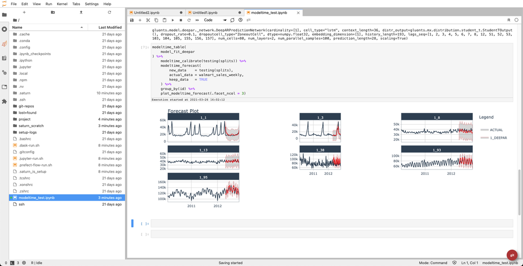

Saturn Cloud GPU Multi-Forecast

[figure not shown]

Event Sponsors

This is a short demonstration of **GPU-Accelerated Deep Learning for Time Series** that was part of the presentation, *“The Future of Time Series | Rise of the High-Performance Forecasting System”*. Video and all supporting contents are provided as part of [**Learning Labs PRO, Lab 53**](https://university.business-science.io/p/learning-labs-pro).

- 7 forecasts (Multi-Forecast) were created using a single GluonTS Model
- This is a demonstration of the **scalability** that can be accomplished as we could implement the same process to forecast 1000’s of time series.

## Code

The code is provided in the `/code` directory:

- `modeltime_test.ipynb` (Jupyter Notebook File) - As demonstrated on the Saturn Cloud Platform
- `modeltime_test.Rmd` (RMarkdown File) - Provided for R-Users that want to run the code locally. Make sure to follow the [“Managing GluonTS Environments” setup instructions here](https://business-science.github.io/modeltime.gluonts/articles/managing-envs.html).

## Modeltime GluonTS

This presentation showcases `modeltime.gluonts` (an R package used for deep learning forecasting with GluonTS as a forecasting backend).

- The [Modeltime GluonTS Documentation](https://business-science.github.io/modeltime.gluonts/) can be found here.
- Modeltime GluonTS is part of the [Modeltime Ecosystem](https://business-science.github.io/modeltime/), a series of R Packages that provide scalable forecasting workflow and infrastructure.

[figure not shown]

Modeltime Ecosystem

## GPU Workspace Setup: Saturn Cloud | NVIDIA GPU

[Saturn Cloud](https://www.saturncloud.io/) enables us to run data science code across multiple machines or with GPUs, then deploy to dashboards, APIs, and scheduled jobs. We used the GPU capability in this lab.

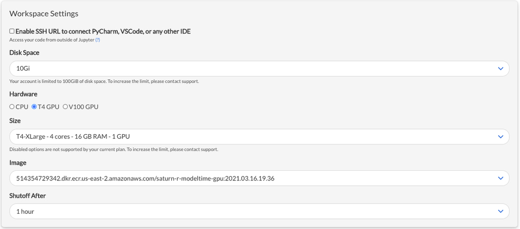

GPU Workspace

### Instructions:

- Go to the [SaturnCloud Platform](https://www.saturncloud.io/) to create a GPU Workspace and Modeltime GluonTS Environment
- Click “Create Custom Project”
- Select the “T4 GPU” type from the Hardware
- Select the Saturn-R-Modeltime-GPU Image (514354729342.dkr.ecr.us-east-2.amazonaws.com/saturn-r-modeltime-gpu:2021.03.16.19.36)
  - Pre-built with Modeltime, R Kernel, and supporting R and Python packages
  - The environment uses MXNET CUDA Backend enabling GluonTS to leverage GPUs and greatly speed-up training
  - The result is training times 2X to 5X faster than on a 12-Core Laptop
- Open the “Advanced Settings” and make the following changes:
  - Copy and paste this command into the “Startup Script” area. These lines let Jupyter Know to use R (and include a fix to a minor package issue)

```
Rscript -e "IRkernel::installspec(user = TRUE)"
sudo Rscript -e "remove.packages('farver')"
sudo Rscript -e "install.packages('farver', repos = 'https://cran.r-project.org')"
```

- Change the “Working Directory” to: `/home/jovyan/`
- Click “Create” - This creates a project. Start the Jupyter Server with the green triangle button (the first time you do this it’ll take a few minutes).
- Once the Jupyter Server is online and the Jupyter Lab button is active, click it to open Jupyter Lab.
- Upload the `modeltime_test.ipynb` Jupyter Notebook and run the code.

## Thanks to our Event Sponsors

This event was sponsored by [Saturn Cloud](https://www.saturncloud.io/), [NVIDIA](https://www.nvidia.com/), and [Business Science](https://www.business-science.io/).

[figure not shown]

Event Sponsors